# R Notebook

install.packages(“ppmSuite”)

```r
library(ppmSuite)
```

# Test ppmSuite

```r
head(ppmSuite::bear)
```

|  | age | length | sex | weight | chest | headlen | headwid | month | neck |
| --- | --- | --- | --- | --- | --- | --- | --- | --- | --- |
| 1 | 19 | 53.0 | 1 | 80 | 26 | 11.0 | 5.5 | 7 | 16.0 |
| 2 | 55 | 67.5 | 1 | 344 | 45 | 16.5 | 9.0 | 7 | 28.0 |
| 3 | 81 | 72.0 | 1 | 416 | 54 | 15.5 | 8.0 | 9 | 31.0 |
| 4 | 115 | 72.0 | 1 | 348 | 49 | 17.0 | 10.0 | 7 | 31.5 |
| 5 | 104 | 62.0 | 2 | 166 | 35 | 15.5 | 6.5 | 8 | 22.0 |
| 6 | 100 | 70.0 | 2 | 220 | 41 | 13.0 | 7.0 | 4 | 21.0 |

```r
# it's a dataset of ppmSuite
# If there is output it means that it works, the package is correctly installed
```

# Test drpm

https://www.tandfonline.com/doi/suppl/10.1080/10618600.2021.1987255?scroll=top devtools::install_github(“https://github.com/gpage2990/drpm.git”)

```r
library(drpm)
library(salso)
```

```r
# preparation
source("include.R") # for having df_agri
```

```
Avvertimento: il pacchetto ‘hash’ è stato creato con R versione 4.2.3hash-2.2.6.3 provided by Decision Patterns
```

[output not shown]

```r
sites = data.frame(
    longitude = unique(df_agri$Longitude)[1:10],
    latitude = unique(df_agri$Latitude)[1:10])

# unique(df_agri[,c("Longitude","Latitude")])[1:10,] == sites[1:10,]
```

# Step 1

## on simulated data

```r
# begin all in the same cluster
y01=matrix(data=rnorm(5,0,1),nrow = 5,ncol = 1)
y02=matrix(data=rnorm(5,0,1),nrow = 5,ncol = 1)
y0 = rbind(y01,y02)

# half in cluster 0, half in cluster 1
y11=matrix(data=rnorm(5,0,1),nrow = 5,ncol = 1)
# cambiato da 10 a 50 così i cluster sono più separati
y12=matrix(data=rnorm(5,50,1),nrow = 5,ncol = 1)
y1 = rbind(y11,y12)

# at time 2 they switch clusters
y21=matrix(data=rnorm(5,50,1),nrow = 5,ncol = 1)
y22=matrix(data=rnorm(5,0,1),nrow = 5,ncol = 1)
y2 = rbind(y21,y22)

# at time 3 they move in a new cluster
y31=matrix(data=rnorm(5,100,1),nrow = 5,ncol = 1)
y32=matrix(data=rnorm(5,100,1),nrow = 5,ncol = 1)
y3 = rbind(y31,y32)

# at time 4 they return to the clusters at 1
y41=matrix(data=rnorm(5,0,1),nrow = 5,ncol = 1)
y42=matrix(data=rnorm(5,50,1),nrow = 5,ncol = 1)
y4 = rbind(y41,y42)

y = cbind(y0,y1,y2,y3,y4)
as.data.frame(y)
```

| V1 | V2 | V3 | V4 | V5 |
| --- | --- | --- | --- | --- |
| -0.95827173 | 1.1110681 | 51.109379 | 99.98353 | 0.6188101 |
| -1.27270316 | 0.8807907 | 49.925400 | 100.07383 | -0.5876430 |
| 0.41738869 | -0.5519346 | 49.767935 | 100.19956 | -0.6209420 |
| -0.16664235 | -0.1175014 | 47.532878 | 100.37815 | -1.0689304 |
| -0.95561620 | 0.9500369 | 48.745852 | 100.91404 | 0.3346551 |
| 1.20539124 | 51.5361300 | 0.356971 | 99.85857 | 50.1155335 |
| -0.34773821 | 49.4177927 | -2.177477 | 99.99490 | 50.0701101 |
| 1.10704631 | 52.9225527 | -1.231400 | 99.32929 | 50.2989587 |
| 0.26607786 | 50.4526669 | 1.464159 | 98.32837 | 49.9090487 |
| -0.09221956 | 49.5289750 | -1.849307 | 98.30316 | 49.9103623 |

```r
cols = colora(size(y)[1],56,0)
for(i in 1:size(y)[1]){
    if(i==1){
        plot(y[i,],col=cols[i],ylim=extrema(y),type="l")
    }
    else{
        lines(y[i,],col=cols[i])
    }
}
abline(h=c(0,50,100),col=cols[1])
```

```r
text(4,0,"CL1")
text(4,50,"CL2")
```

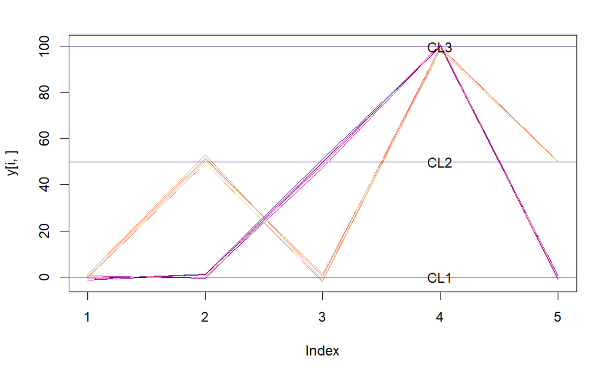

```r
text(4,100,"CL3")
```

```r
fit_sim <- drpm_fit(y,
        s_coords = NULL, # per ora cerchiamo solo di capire i cluster, senza spatial effect
        M=1,
        initial_partition = NULL,
        starting_alpha = 0.5,
        unit_specific_alpha = FALSE,
        time_specific_alpha = TRUE,
        alpha_0=FALSE,
        eta1_0=FALSE,
        phi1_0=FALSE,
        modelPriors=c(40,100^2,1,1,1,1),
        alphaPriors=rbind(c(1,1)),
        simpleModel = 0,
        theta_tau2 = c(0, 2),
        SpatialCohesion=4,
        cParms=c(0, 1, 2, 1),
        mh=c(0.5, 1, 0.1, 0.1, 0.1),
        verbose=TRUE,
        draws=1100,burn=100,thin=1)
```

```
sPPM =  FALSE
ntime =  5
ntime_out =  5
nsubject = 10
ntime = 5
nout = 1000
update_alpha = 1
update_eta1 = 1
update_phi1 = 1
Prior values: Asig = 1.00, Atau = 1.00, Alam = 1.00,
 m0 = 40.00, s20 = 10000.00

ntime =  5
ntime_out =  5
```

## understand salso

```r
names(fit_sim)
```

```
 [1] "Si"                "gamma"             "mu"                "sig2"
 [5] "alpha"             "theta"             "tau2"              "eta1"
 [9] "phi0"              "phi1"              "lam2"              "llike"
[13] "fitted"            "lpml"              "waic"              "initial_partition"
```

```r
size(fit_sim$Si)
```

```
[1]    5   10 1000
```

```r
# ?salso
```

Salso wants - as x a B*n matrix, where B stands for the MCMC iterates, and the n cols stands for the cluster assigned to the units (in that MCMC iterate). So there is no time account here, in salso (while there was in the model). So maybe we just have to extract the best partition at each time. Le partizioni di salso non dipendono dal tempo, ma quelle generate da drpm_fit sì, quindi non è che il tempo “scompare”, resta presente nell’input che diamo a salso.

For example here we get, for time instant 1, the 1000 simulated values for the clustering of our 10 units. Indeed they all started at the same level so makes sense they are in cluster 1 all.

```r
cat("Requested size by salso: ")
```

```
Requested size by salso:
```

```r
size(t(fit_sim$Si[1,,]))
```

```
[1] 1000   10
```

```r
for(time in 1:5){
    cat("\nTime",time,"\n")
    if(time==1) cat("all the same cluster\n")
    if(time==2) cat("two clusters separated\n")
    if(time==3) cat("again two clusters separated, but the cluster index does not change, as indeed the observations dont mix, they follow different paths.\nCioè quelle che prima erano alte ora scendono, ma non per questo il loro cluster number deve cambiare.\nPrima erano cluster 2 e ora rimangano cluster 2 anche sono \"in basso\".\n")
    if(time==4) cat("all the same cluster\n")
    if(time==5) cat("again two clusters\n")

print(t(fit_sim$Si[time,,])[1:10,])
}
```

```
Time 1
all the same cluster
      [,1] [,2] [,3] [,4] [,5] [,6] [,7] [,8] [,9] [,10]
 [1,]    1    1    1    1    1    1    1    1    1     1
 [2,]    1    1    1    1    1    1    1    1    1     1
 [3,]    1    1    1    1    1    1    1    1    1     1
 [4,]    1    1    1    1    1    1    1    1    1     1
 [5,]    1    1    1    1    1    1    1    1    1     1
 [6,]    1    1    1    1    1    1    1    1    1     1
 [7,]    1    1    1    1    1    1    1    1    1     1
 [8,]    1    1    1    1    1    1    1    1    1     1
 [9,]    1    1    1    1    1    1    1    1    1     1
[10,]    1    1    1    1    1    1    1    1    1     1

Time 2
```

[output cut: 56 more lines]

## get final best partitions

```r
cat("We had units from 1 to 10.\n")
```

```
We had units from 1 to 10.
```

```r
for (time in 1:5){
    cat("\nBest partition at time",time,"is\n")
    salso_out = suppressWarnings({
        salso( x =t(fit_sim$Si[time,,]), loss = "binder")
    })
    cat(salso_out)
}
```

```
Best partition at time 1 is
1 1 1 1 1 1 1 1 1 1
Best partition at time 2 is
1 1 1 1 1 2 2 2 2 2
Best partition at time 3 is
1 1 1 1 1 2 2 2 2 2
Best partition at time 4 is
1 1 1 1 1 1 1 1 1 1
Best partition at time 5 is
1 1 1 1 1 2 2 2 2 2
```

# Step 1.5

## on simulated mixing data

as the example of step 1 but with interlacing data, like this:

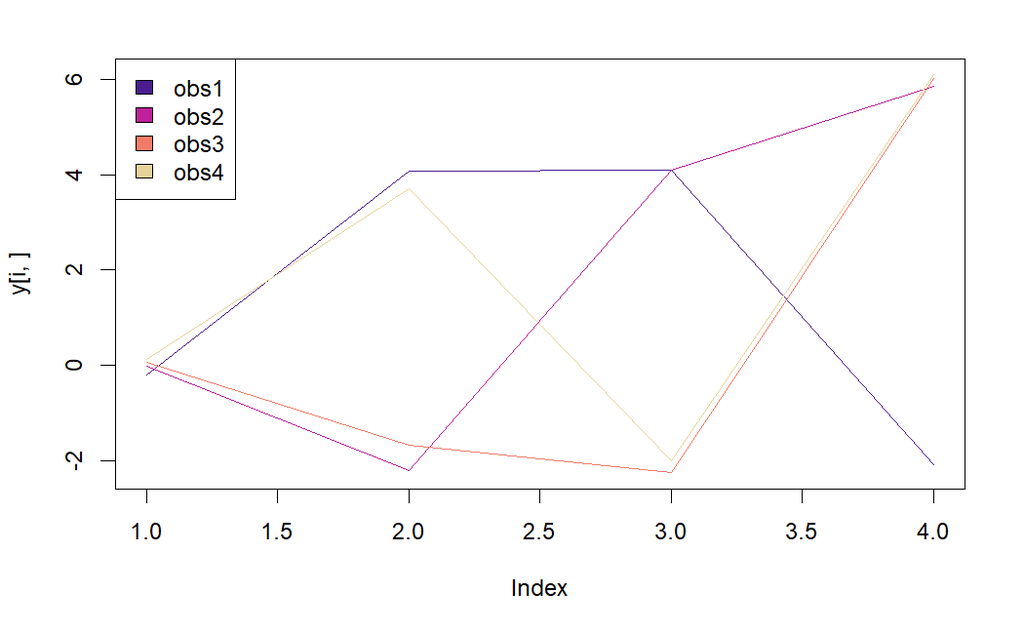

```r
sigma2 = 0.2
y0 = c(0,0,0,0)+rnorm(4,0,sigma2)   # all same cluster
y1 = c(4,-2,-2,4)+rnorm(4,0,sigma2) # cluster 1&4, 2&3
y2 = c(4,4,-2,-2)+rnorm(4,0,sigma2) # cluster 1&2, 3&4
y3 = c(-2,6,6,6)+rnorm(4,0,sigma2)  # cluster 1, 2&3&4

y = cbind(y0,y1,y2,y3)

cols = colora(size(y)[1],56,0)
for(i in 1:size(y)[1]){
    if(i==1){
        plot(y[i,],col=cols[i],ylim=extrema(y),type="l")
    }
    else{
        lines(y[i,],col=cols[i])
    }
}
legend("topleft",c("obs1","obs2","obs3","obs4"),fill=cols)
```

```r
# 1 point 5, the step
fit_sim_1p5 <- drpm_fit(y,
        s_coords = NULL, # per ora cerchiamo solo di capire i cluster, senza spatial effect
        M=1,
        initial_partition = NULL,
        starting_alpha = 0.5,
        unit_specific_alpha = FALSE,
        time_specific_alpha = TRUE,
        alpha_0=FALSE,
        eta1_0=FALSE,
        phi1_0=FALSE,
        modelPriors=c(40,100^2,1,1,1,1),
        alphaPriors=rbind(c(1,1)),
        simpleModel = 0,
        theta_tau2 = c(0, 2),
        SpatialCohesion=4,
        cParms=c(0, 1, 2, 1),
        mh=c(0.5, 1, 0.1, 0.1, 0.1),
        verbose=TRUE,
        draws=1100,burn=100,thin=1)
```

```
sPPM =  FALSE
ntime =  4
ntime_out =  4
nsubject = 4
ntime = 4
nout = 1000
update_alpha = 1
update_eta1 = 1
update_phi1 = 1
Prior values: Asig = 1.00, Atau = 1.00, Alam = 1.00,
 m0 = 40.00, s20 = 10000.00

ntime =  4
ntime_out =  4
```

```r
cat("We had units from 1 to 4.\n")
```

```
We had units from 1 to 4.
```

```r
for (time in 1:size(y)[1]){
    cat("\nBest partition at time",time,"is\n")
    salso_out = suppressWarnings({
        salso( x =t(fit_sim_1p5$Si[time,,]), loss = "binder")
    })
    cat(salso_out)
    if(time == 1) cat(" (all same cluster)")
    if(time == 2) cat(" (cluster 1&4, 2&3)")
    if(time == 3) cat(" (cluster 1&2, 3&4)")
    if(time == 4) cat(" (cluster 1, 2&3&4)")
}
```

```
Best partition at time 1 is
1 1 1 1 (all same cluster)
Best partition at time 2 is
1 2 2 1 (cluster 1&4, 2&3)
Best partition at time 3 is
1 1 2 2 (cluster 1&2, 3&4)
Best partition at time 4 is
1 2 2 2 (cluster 1, 2&3&4)
```

```r
summary(salso_out)
```

```
$estimate
[1] 1 2 2 2
attr(,"info")
   loss a maxNClusters expectedLoss initMethod nScans nZAcc nZAtt nRuns   seconds
 binder 1            4     0.199875      empty      1     0     1    16 0.0020114

$nClusters
[1] 2

$score
[1] 0.0000 0.0300 0.0855 0.0760

$order
[1] 1 3 4 2

$dendrogram
'dendrogram' with 2 branches and 2 members total, at height 0.5

$psm
      [,1]  [,2]  [,3]  [,4]
[1,] 1.000 0.464 0.387 0.365
[2,] 0.464 1.000 0.848 0.829
[3,] 0.387 0.848 1.000 0.940
[4,] 0.365 0.829 0.940 1.000

$meanPS
[1] 1.0000000 0.8923333 0.9293333 0.9230000

$meanPSM
          [,1]      [,2]
[1,]       NaN 0.4053333
[2,] 0.4053333 0.8723333

$exemplar
1 2
1 3

$sizes
1 2
1 3

attr(,"class")
[1] "salso.summary"
```

# Step 2

## on simulated spatial data

o forse no passiamo direttamente allo step 3.

# Step 3 (?)

## on df_weekly

df_weekly già caricato da include.R

```r
stations = unique(df_weekly$IDStations)

y=data.frame()

sites = data.frame(
    longitude = unique(df_weekly$Longitude),
    latitude = unique(df_weekly$Latitude))

for(st in stations){
  y_we_pm10=cbind(as.data.frame(st),t(df_weekly[which(df_weekly$IDStations==st),7]))
  y=rbind(y,y_we_pm10)
}

rownames(y) = NULL
colnames(y)<- c("id",paste0("w", 1:53))
y
```

| id | w1 | w2 | w3 | w4 | w5 | w6 | w7 | w8 | w9 | w10 | w11 | w12 | w13 | w14 | w15 | w16 | w17 | w18 | w19 | w20 | w21 | w22 | w23 | w24 | w25 | w26 | w27 | w28 | w29 | … |
| --- | --- | --- | --- | --- | --- | --- | --- | --- | --- | --- | --- | --- | --- | --- | --- | --- | --- | --- | --- | --- | --- | --- | --- | --- | --- | --- | --- | --- | --- | --- |
| 1264 | 37.714286 | 33.571429 | 32.000000 | 43.285714 | 32.571429 | 31.57143 | 37.142857 | 40.571429 | 38.14286 | 33.142857 | 16.142857 | 21.142857 | 21.000000 | 17.571429 | 14.142857 | 18.50000 | 24.42857 | 15.33333 | 13.833333 | 11.714286 | 15.000000 | 16.50000 | 14.750000 | 15.428571 | 16.857143 | 14.714286 | 14.571429 | 14.71429 | 12.428571 | … |
| 1265 | 40.571429 | 36.142857 | 43.714286 | 56.571429 | 28.428571 | 35.14286 | 47.714286 | 29.285714 | 46.14286 | 37.857143 | 20.714286 | 25.000000 | 37.428571 | 20.000000 | 18.142857 | 37.42857 | 33.71429 | 20.42857 | 21.857143 | 15.857143 | 25.285714 | 24.00000 | 17.714286 | 21.142857 | 19.714286 | 17.857143 | 18.166667 | 23.57143 | 17.857143 | … |
| 1266 | 39.571429 | 35.285714 | 38.428571 | 57.428571 | 24.142857 | 32.57143 | 52.333333 | 26.714286 | 45.28571 | 36.857143 | 18.571429 | 24.714286 | 34.000000 | 28.285714 | 16.714286 | 37.00000 | 34.14286 | 19.00000 | 20.666667 | 16.714286 | 25.142857 | 25.14286 | 16.000000 | 21.000000 | 20.571429 | 16.857143 | 18.285714 | 27.00000 | 17.000000 | … |
| 1269 | 36.428571 | 34.714286 | 43.000000 | 57.714286 | 37.857143 | 35.00000 | 44.600000 | 36.666667 | 50.57143 | 40.285714 | 23.857143 | 33.428571 | 33.142857 | 30.285714 | 17.500000 | 37.28571 | 36.85714 | 20.28571 | 17.428571 | 16.666667 | 21.857143 | 22.85714 | 21.428571 | 18.857143 | 19.571429 | 17.000000 | 22.250000 | 25.00000 | 15.571429 | … |
| 1297 | 44.857143 | 40.666667 | 47.857143 | 64.142857 | 30.714286 | 39.71429 | 49.571429 | 31.166667 | 52.66667 | 44.428571 | 21.800000 | 30.428571 | 37.857143 | 29.857143 | 22.500000 | 36.42857 | 39.28571 | 23.42857 | 24.285714 | 18.428571 | 29.285714 | 29.28571 | 19.800000 | 24.142857 | 23.000000 | 21.000000 | 22.857143 | 29.71429 | 26.166667 | … |
| 1374 | 31.142857 | 35.000000 | 34.285714 | 62.000000 | 43.800000 | 34.57143 | 54.285714 | 29.428571 | 44.00000 | 38.666667 | 36.000000 | 24.500000 | 27.142857 | 31.250000 | 25.000000 | 26.20000 | 27.40000 | 19.00000 | 20.333333 | 7.800000 | 31.250000 | 17.14286 | 13.285714 | 32.500000 | 17.000000 | 10.428571 | 18.000000 | 16.50000 | 10.250000 | … |
| 517 | 33.714286 | 30.142857 | 38.571429 | 51.285714 | 38.142857 | 33.57143 | 55.571429 | 32.000000 | 48.42857 | 35.857143 | 16.714286 | 26.142857 | 26.714286 | 21.571429 | 10.857143 | 31.28571 | 29.85714 | 15.42857 | 10.714286 | 7.250000 | 15.053571 | 22.85714 | 13.000000 | 17.571429 | 18.428571 | 16.833333 | 16.000000 | 18.28571 | 13.571429 | … |
| 528 | 40.428571 | 40.428571 | 47.571429 | 61.428571 | 39.666667 | 34.57143 | 55.714286 | 32.714286 | 47.33333 | 36.714286 | 22.571429 | 28.666667 | 43.333333 | 33.714286 | 19.571429 | 43.40000 | 37.60000 | 24.16667 | 20.571429 | 15.571429 | 29.142857 | 26.14286 | 20.428571 | 23.285714 | 24.000000 | 22.285714 | 22.000000 | 25.42857 | 21.142857 | … |
| 531 | 49.800000 | 39.857143 | 47.714286 | 65.857143 | 27.500000 | 34.00000 | 57.571429 | 33.600000 | 45.28571 | 38.333333 | 19.142857 | 26.800000 | 35.571429 | 30.428571 | 18.000000 | 43.83333 | 31.71429 | 20.71429 | 19.571429 | 12.666667 | 24.000000 | 21.71429 | 17.000000 | 20.571429 | 20.428571 | 17.857143 | 20.333333 | 22.42857 | 18.285714 | … |
| 542 | 42.000000 | 42.142857 | 45.285714 | 67.857143 | 43.200000 | 43.14286 | 59.142857 | 37.000000 | 44.85714 | 40.142857 | 22.800000 | 31.857143 | 32.714286 | 28.857143 | 14.285714 | 34.50000 | 32.85714 | 18.71429 | 17.571429 | 13.142857 | 21.714286 | 21.42857 | 18.000000 | 21.285714 | 26.000000 | 23.000000 | 17.428571 | 20.42857 | 16.428571 | … |

[output cut: 95 more lines]

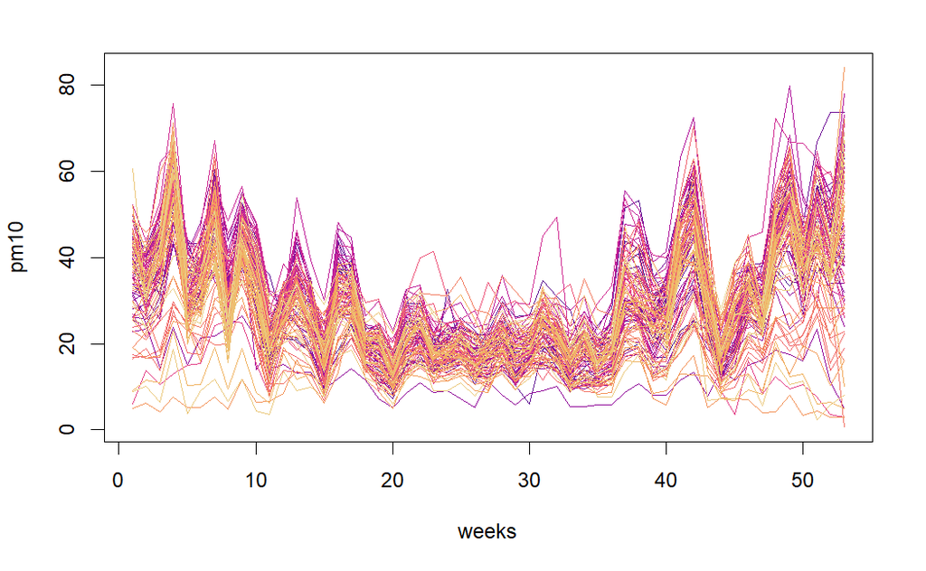

```r
yred=y[,2:54]
cols = colora(size(yred)[1],56,0)
for(i in 1:size(yred)[1]){
   if(i==1){
     plot(1:size(yred)[2],yred[i,],col=cols[i],ylim=extrema(yred),type='l',xlab='weeks',ylab='pm10')
      }
      else{
          lines(1:size(yred)[2],yred[i,],col=cols[i])
      }
}
```

## fit

```r
drpm1 <- drpm_fit(y[,2:54],
         M=1,
         initial_partition = NULL,
         starting_alpha = 0.5,
         unit_specific_alpha = FALSE,
         time_specific_alpha = TRUE,
         alpha_0=FALSE,
         eta1_0=FALSE,
         phi1_0=FALSE,
         modelPriors=c(40,100^2,1,1,1,1),
         alphaPriors=rbind(c(1,1)),
         simpleModel = 0,
         theta_tau2 = c(0, 2),
         SpatialCohesion=4,
         cParms=c(0, 1, 2, 1),
         mh=c(0.5, 1, 0.1, 0.1, 0.1),
         verbose=TRUE,
         draws=1100,burn=100,thin=1)
```

```
sPPM =  FALSE
ntime =  53
ntime_out =  53
nsubject = 105
ntime = 53
nout = 1000
update_alpha = 1
update_eta1 = 1
update_phi1 = 1
Prior values: Asig = 1.00, Atau = 1.00, Alam = 1.00,
 m0 = 40.00, s20 = 10000.00

ntime =  53
ntime_out =  53
```

```r
names(drpm1)
```

```
 [1] "Si"                "gamma"             "mu"                "sig2"
 [5] "alpha"             "theta"             "tau2"              "eta1"
 [9] "phi0"              "phi1"              "lam2"              "llike"
[13] "fitted"            "lpml"              "waic"              "initial_partition"
```

```r
size(drpm1$Si)
# questa cos ha le simulazioni dei cluster assegnati
# ha dimensione 53 righe, 105 colonne, 1000 volte, perché
# - per ognuna delle 1000 iterazioni delle MCMC
# - dà i cluster assegnati dalla simulazione per le stazioni in quella simulazione
```

## study cluster division

check morale di cosa intende quella divisione.

```r
summary(salso_out)
```

[output not shown]

[output cut: 151 more lines]

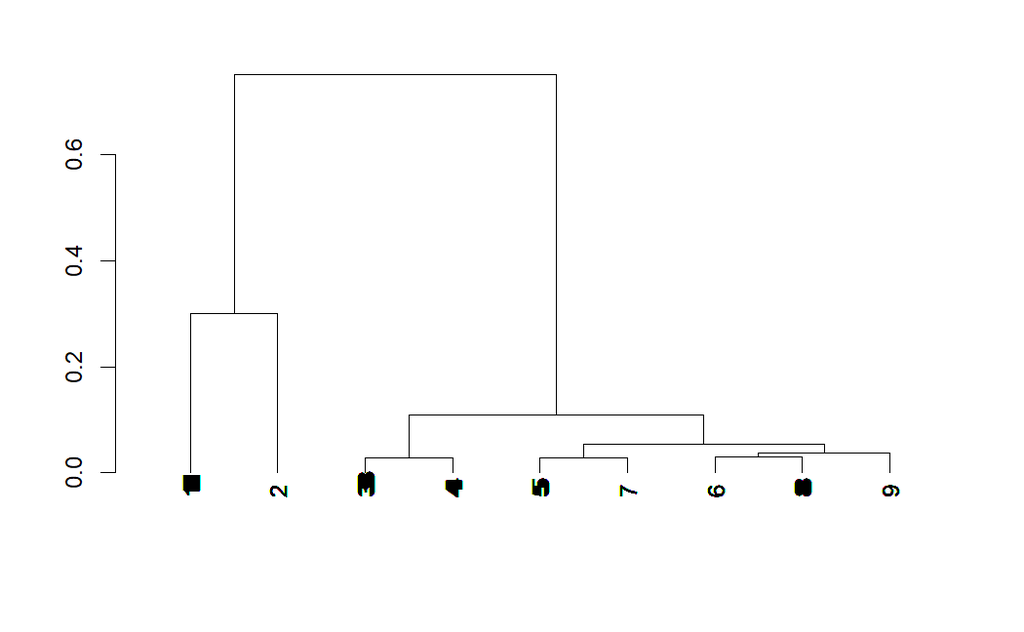

Sembra ci siano molti cluster piccoli, quindi forse occorre capire le prior/i parametri di drpm_fit per aggiustare questo fenomeno.

```
Time 1
Cluster 1 - size 34 - mean 38.25686
Cluster 2 - size 35 - mean 45.79537
Cluster 3 - size 14 - mean 32.04592
Cluster 4 - size 2 - mean 28.311
Cluster 5 - size 7 - mean 25.75714
Cluster 6 - size 3 - mean 23.2381
Cluster 7 - size 1 - mean 26.85714
Cluster 8 - size 4 - mean 7.214286
Cluster 9 - size 5 - mean 17.70254
Time 2
Cluster 1 - size 10 - mean 33.34286
Cluster 2 - size 15 - mean 33.33513
Cluster 3 - size 11 - mean 39.45195
Cluster 4 - size 10 - mean 33.24857
Cluster 5 - size 10 - mean 29.82363
Cluster 6 - size 8 - mean 45.45119
Cluster 7 - size 24 - mean 32.92044
Cluster 8 - size 8 - mean 42.95714
Cluster 9 - size 7 - mean 42.14286
Cluster 10 - size 2 - mean 56.28571
Time 3
Cluster 1 - size 5 - mean 32.5673
Cluster 2 - size 22 - mean 41.92165
Cluster 3 - size 1 - mean 39.57143
Cluster 4 - size 6 - mean 38.66667
Cluster 5 - size 17 - mean 38.99748
Cluster 6 - size 11 - mean 30.94589
Cluster 7 - size 3 - mean 39.38095
Cluster 8 - size 8 - mean 35.98214
Cluster 9 - size 2 - mean 37.42857
Cluster 10 - size 11 - mean 20.62884
Cluster 11 - size 5 - mean 35.50857
Cluster 12 - size 7 - mean 43.36735
Cluster 13 - size 2 - mean 36.21429
Cluster 14 - size 1 - mean 44.71429
Cluster 15 - size 1 - mean 40.28571
Cluster 16 - size 1 - mean 37.85714
Cluster 17 - size 2 - mean 29.42857
Time 4
```

[output cut: 91 more lines]

```
Cluster 3 - size 6 - mean 32.4119
Cluster 4 - size 18 - mean 36.6082
Cluster 5 - size 12 - mean 39.44072
Cluster 6 - size 5 - mean 32.91429
Cluster 7 - size 2 - mean 41.04286
Cluster 8 - size 5 - mean 37.61714
Cluster 9 - size 4 - mean 37.75
Cluster 10 - size 6 - mean 25.16164
Cluster 11 - size 2 - mean 36.78571
Cluster 12 - size 4 - mean 38.27381
Cluster 13 - size 2 - mean 19.57143
Cluster 14 - size 2 - mean 37
Cluster 15 - size 5 - mean 36.65714
Cluster 16 - size 2 - mean 44.78571
Cluster 17 - size 2 - mean 12
```

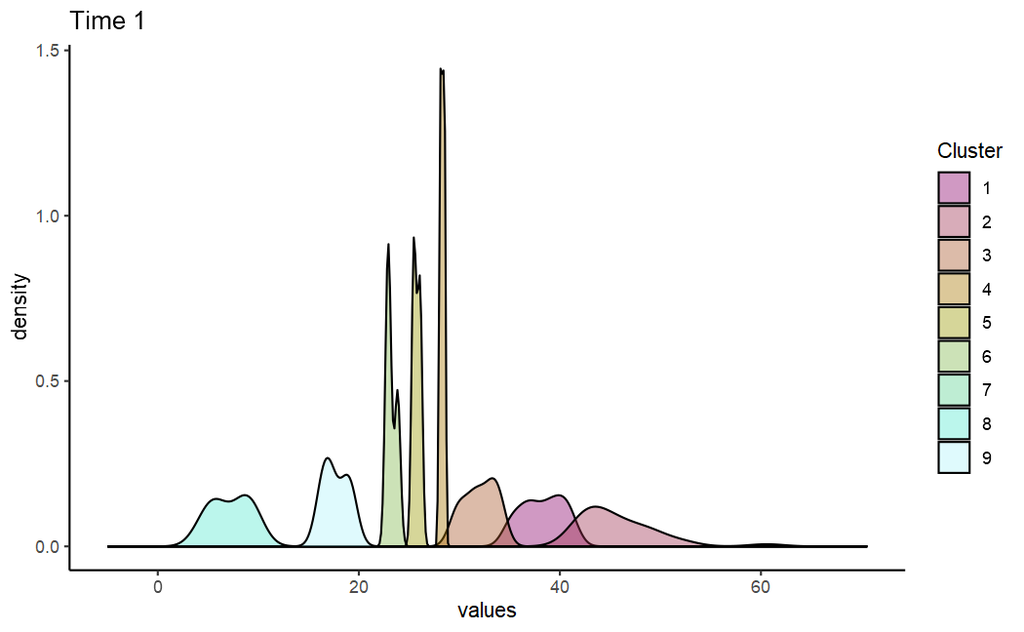

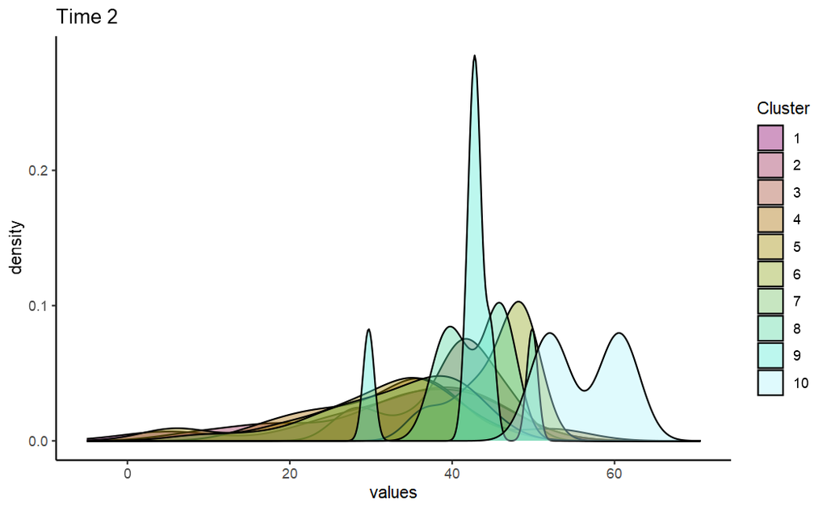

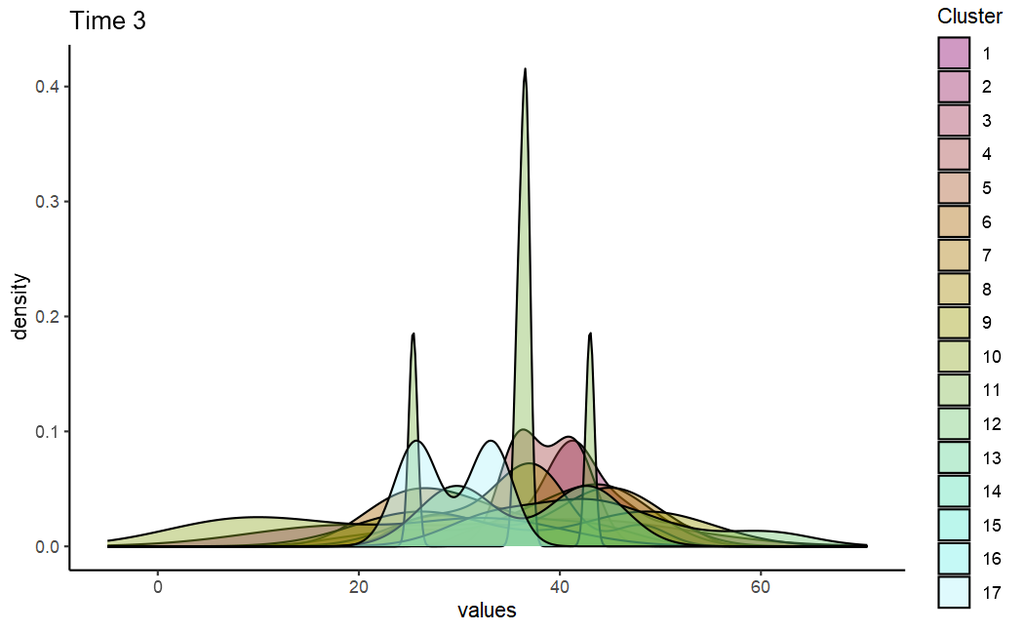

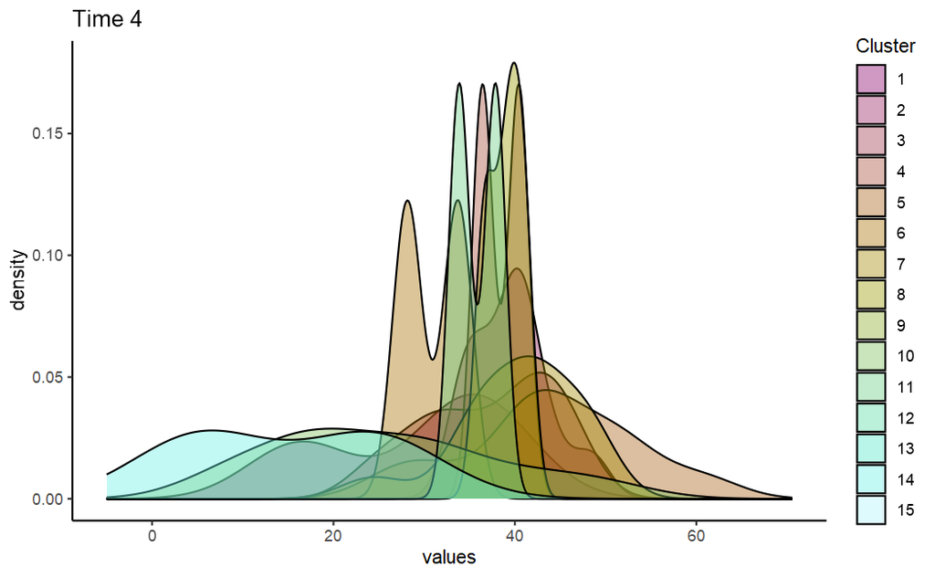

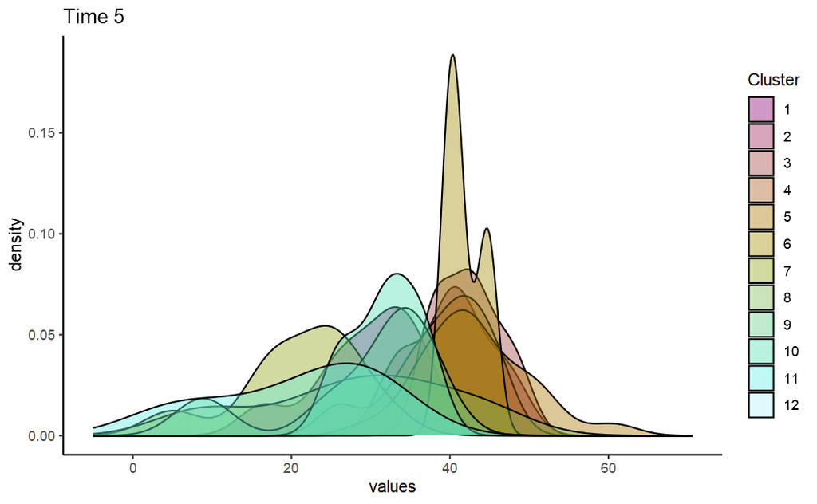

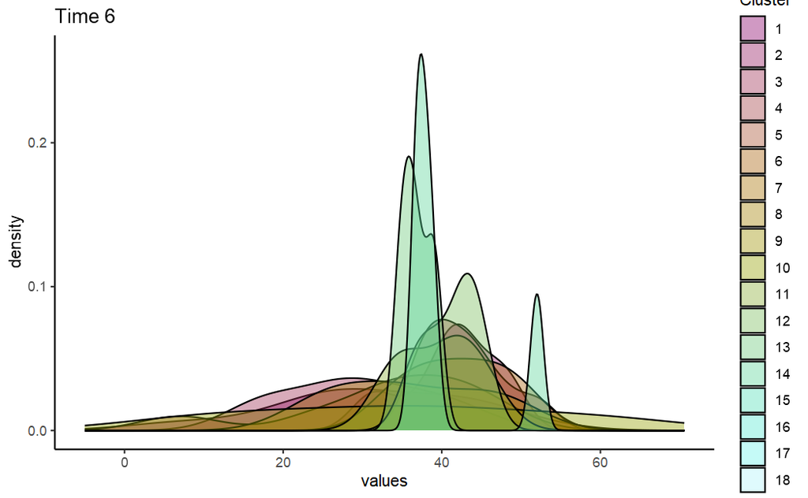

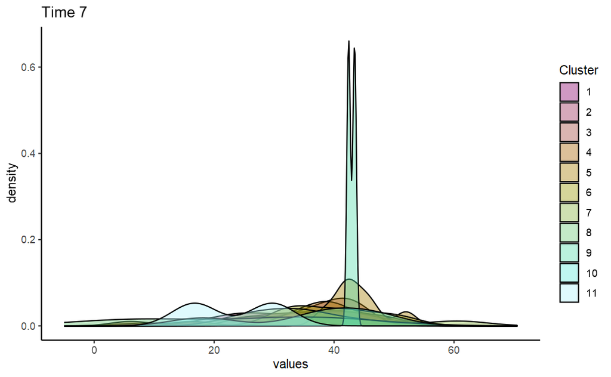

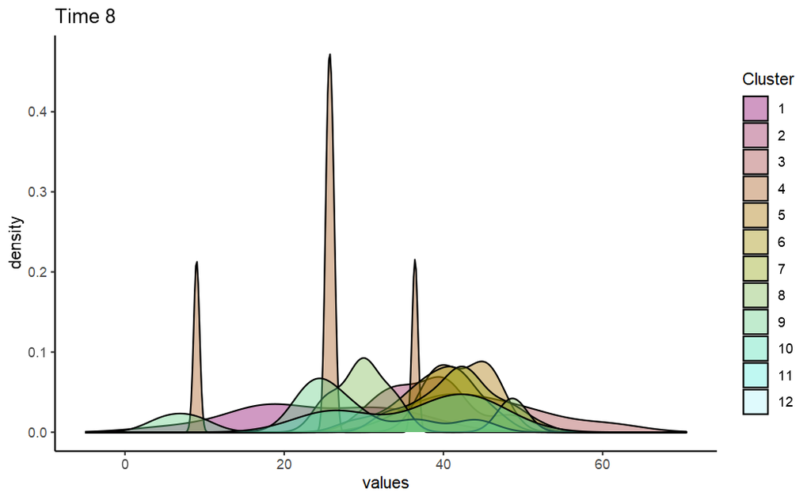

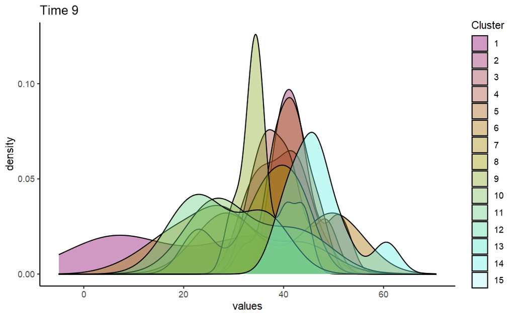

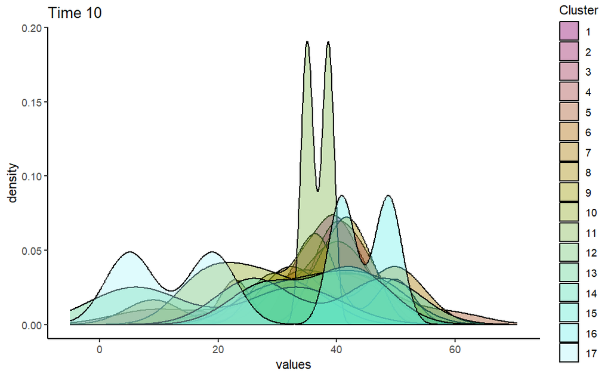

```r
# time = 1
for(time in 1:10){

salso_out <- salso(t(drpm1$Si[time,,]),loss="binder")

n_clusters = max(salso_out)
cat(crayon::cyan("Time",time,"\n"))
for (cl in 1:n_clusters){
    cat("Cluster",cl,"- size",length(y$w1[which(salso_out==cl)]),
        "- mean",mean(y$w1[which(salso_out==cl)]),"\n")
}
# ci sta, sembrano abbastanza diverse

# ora creiamo un dataset che ha (105 righe e) due colonne: i valori di pm10, e il cluster assegnato
clust_vals = list()
for(cl in 1:n_clusters){
    clust_vals[[cl]] <- data.frame(values = y$w1[which(salso_out==cl)])
    clust_vals[[cl]]$cluster = as.factor(cl)
}

valori = clust_vals[[1]]
for(cl in 2:n_clusters){
    valori = rbind(valori, clust_vals[[cl]])
}

# per ora stiamo lavorando sui valori del dataset,
# ma dobbiamo ricordarci che li dobbiamo log-trasformare in realtà

# p = ggplot(valori, aes(log(values), fill = cluster)) +
p = ggplot(valori, aes(values, fill = cluster)) +
    # scale_color_discrete(name = "cluster")+
    # scale_fill_brewer(type="div",palette=4)+
    scale_fill_manual(values = colora(n_clusters,77,0),name="Cluster")+
    geom_density(alpha = 0.4)+
    ggtitle(paste("Time",time))+
    xlim(extrema(valori$values)+c(-10,10))+
    theme_classic()
print(p)

} # end for(time in eccc)
```

## simple evolution plot

```r
source("plot functions/plot_utilities.R")
```

[output not shown]

```r
df_temp$clusters
```

```
  [1] 1  1  1  1  1  1  1  1  1  1  1  2  2  2  2  2  2  2  2  2  2  2  2  2  2  2  2  2  3  3  3
 [32] 3  3  3  4  4  4  4  4  4  4  4  4  4  4  4  4  4  4  4  4  4  5  5  5  5  5  5  5  5  5  5
 [63] 5  5  6  6  6  6  6  7  7  8  8  8  8  8  9  9  9  9  10 10 10 10 10 10 11 11 12 12 12 12 13
 [94] 13 14 14 15 15 15 15 15 16 16 17 17
Levels: 1 2 3 4 5 6 7 8 9 10 11 12 13 14 15 16 17
```

## old code

```r
rho <- list()
for(t in 1:size(y[,2:54])[2]){
    rho[[t]] <- salso(t(drpm1$Si[t,,]),
                      #structure="clustering",
                      loss="binder")
}
rho
```